# Preparation bulkRNAseq analyses

Accompanying ‘AE_TEMPLATE’

[Sander W. van der Laan, PhD](https://vanderlaan.science) | s.w.vanderlaan@gmail.com

2023-06-14

# General Setup

```
Create a new analysis directories.

- general directory

- for plots

- for output of summary results

- for baseline tables

- for genetic analyses

- for Cox regression results
```

```r
source("scripts/functions.R")
```

```r
source("scripts/pack02.packages.R")
```

```
* General packages...

* Genomic packages...
```

```r
Today = format(as.Date(as.POSIXlt(Sys.time())), "%Y%m%d")
Today.Report = format(as.Date(as.POSIXlt(Sys.time())), "%A, %B %d, %Y")

source("scripts/colors.R")
```

# ERA-CVD ‘druggable-MI-targets’

Plaque samples are derived from carotid endarterectomies as part of the [Athero-Express Biobank Study](https://doi.org/10.1007/s10564-004-2304-6) which is an ongoing study in the UMC Utrecht.

## This notebook

In this notebook we setup the files for the bulk RNAseq analyses.

## Background

Here we obtain data from the PCSK9 in plaques.

- `Genes.xlsx` - list of genes of interest.
- `Variants.xlsx` - list of variant(s) of interest.

```r
library(openxlsx)

gene_list_df <- read.xlsx(paste0(TARGET_loc, "/targets.xlsx"), sheet = "Genes")

gene_list <- unlist(gene_list_df$Gene)
gene_list
```

```
[1] "CXCL10" "PCSK9"  "COL4A1" "COL4A2" "COL3A"  "COL2A"  "LDLR"   "CD36"
```

```r
variant_list <- read.xlsx(paste0(TARGET_loc, "/targets.xlsx"), sheet = "Variants")

DT::datatable(variant_list)
```

|  | RSID | ALTID | VariantID | Chr | BP | VariantType | Comments |
| --- | --- | --- | --- | --- | --- | --- | --- |
| 1 | rs11206510 | --- | 1:55496039 | 1 | 55496039 | single nucleotide variant |  |
| 2 | rs11591147 | R46L | 1:55505647 | 1 | 55505647 | single nucleotide variant |  |
| 3 | rs11583680 | A53V | 1:55505668 | 1 | 55505668 | single nucleotide variant |  |
| 4 | rs562556 | V474I | 1:55524237 | 1 | 55524237 | single nucleotide variant |  |
| 5 | rs505151 | G670E | 1:55529187 | 1 | 55529187 | single nucleotide variant |  |

```r
NA
```

# Load data

First we will load the data:

- bulk RNA sequencing (RNAseq) experimental data from carotid plaques
- Athero-Express clinical data.

## Bulk RNAseq data

Here we load the latest dataset from our Athero-Express bulk RNA experiment d.d. 2023-04-07 mapped against cDNA reference of all transcripts in GRCh38.p13 and Ensembl 108 (GRCh38.p13/ENSEMBL_GENES_108 accessed on 18-01-2023). These include raw read counts of all non-ribosomal, protein coding genes with existing HGNC gene name. All read counts are corrected for UMI sampling by `raw.genecounts=round(-4096*(log(1-(raw.genecounts/4096))))` (note that `log` in this case equals ‘natural logarithm’, i.e. `ln`). These data include the patients that passed the QC based on [Mokry, M., Boltjes, A., Slenders, L. *et al.* Nat Cardiovasc Res 1, 1140–1155 (2022)](https://doi.org/10.1038/s44161-022-00171-0)

These bulk RNAseq data are filtered and corrected:

- UMI corrected
- unmappable genes are excluded

However, pre-processing of the data may be required for some analyses. Usually, a normalisation for sequencing depth and quantile normalisation is recommended.

```r
# bulk RNAseq data; first run
bulkRNA_counts_raw_qc_umicorr_firstrun <- fread(paste0(AERNA_loc,"/FIRSTRUN/raw_data_bulk/raw_counts_batch1till11_qc_umicorrected.txt"))
# bulk RNAseq data; re-run (deeper sequenced)
bulkRNA_counts_raw_qc_umicorr <- fread(paste0(AERNA_loc,"/RERUN/PROCESSED/AE_bulk_RNA_batch1.minRib.PC_07042023.txt"))

# batch information
bulkRNA_meta <- fread(paste0(AERNA_loc,"/FIRSTRUN/raw_data_bulk/metadata_raw_counts_batch1till11.txt"))
```

Quick peek at the counts and meta-data of the RNAseq experiment.

```r
head(bulkRNA_counts_raw_qc_umicorr_firstrun)
```

| ENSEMBL_gene_ID | ae1618 | ae2089 | ae2276 | ae3146 | ae758 | ae865 | ae1182 | ae1218 | ae207 | ae2327 | ae300 | ae41 | ae996 | ae1431 | ae1602 | ae1661 | ae2433 | ae460 | ae946 | ae1524 | ae2014 | ae260 | ae63 | ae683 | ae770 | ae117 | ae1286 | ae1722 | ae1936 | … |
| --- | --- | --- | --- | --- | --- | --- | --- | --- | --- | --- | --- | --- | --- | --- | --- | --- | --- | --- | --- | --- | --- | --- | --- | --- | --- | --- | --- | --- | --- | --- |
| ENSG00000000003 | 23 | 15 | 18 | 62 | 18 | 15 | 1 | 36 | 21 | 70 | 27 | 38 | 48 | 54 | 45 | 25 | 100 | 48 | 5 | 6 | 134 | 6 | 32 | 6 | 6 | 11 | 168 | 26 | 20 | … |
| ENSG00000000419 | 2 | 1 | 2 | 7 | 6 | 1 | 0 | 2 | 0 | 12 | 7 | 4 | 1 | 4 | 1 | 1 | 14 | 3 | 1 | 2 | 6 | 0 | 2 | 0 | 1 | 1 | 7 | 1 | 0 | … |
| ENSG00000000457 | 162 | 106 | 63 | 301 | 151 | 140 | 84 | 205 | 220 | 413 | 416 | 308 | 272 | 321 | 262 | 188 | 595 | 285 | 132 | 58 | 820 | 89 | 248 | 93 | 107 | 196 | 617 | 379 | 142 | … |
| ENSG00000000460 | 8 | 3 | 6 | 30 | 8 | 8 | 1 | 10 | 4 | 20 | 12 | 16 | 19 | 12 | 15 | 5 | 39 | 16 | 4 | 4 | 31 | 3 | 11 | 1 | 2 | 4 | 56 | 11 | 6 | … |
| ENSG00000000938 | 12 | 1 | 0 | 2 | 51 | 30 | 8 | 1 | 10 | 40 | 67 | 8 | 3 | 1 | 1 | 1 | 73 | 0 | 24 | 0 | 10 | 0 | 0 | 0 | 0 | 22 | 0 | 19 | 0 | … |
| ENSG00000000971 | 27 | 7 | 12 | 45 | 75 | 30 | 2 | 19 | 32 | 63 | 295 | 32 | 39 | 14 | 20 | 16 | 68 | 19 | 23 | 4 | 76 | 3 | 19 | 5 | 19 | 73 | 61 | 19 | 7 | … |

```r
head(bulkRNA_counts_raw_qc_umicorr)
```

| gene | ae1 | ae1026 | ae1029 | ae1032 | ae1035 | ae1054 | ae1055 | ae1066 | ae107 | ae1074 | ae1082 | ae1100 | ae112 | ae1122 | ae113 | ae1139 | ae114 | ae1140 | ae1155 | ae1157 | ae116 | ae1160 | ae117 | ae1173 | ae1174 | ae1178 | ae1182 | ae1188 | ae1199 | … |
| --- | --- | --- | --- | --- | --- | --- | --- | --- | --- | --- | --- | --- | --- | --- | --- | --- | --- | --- | --- | --- | --- | --- | --- | --- | --- | --- | --- | --- | --- | --- |
| ENSG00000000005 | 0 | 0 | 0 | 1 | 0 | 1 | 0 | 0 | 0 | 0 | 0 | 1 | 1 | 3 | 1 | 0 | 0 | 0 | 2 | 2 | 0 | 1 | 0 | 1 | 2 | 0 | 0 | 2 | 0 | … |
| ENSG00000000419 | 248 | 206 | 71 | 32 | 95 | 141 | 211 | 123 | 58 | 159 | 39 | 213 | 116 | 561 | 100 | 92 | 46 | 59 | 129 | 617 | 89 | 210 | 55 | 600 | 223 | 255 | 28 | 159 | 78 | … |
| ENSG00000000457 | 116 | 301 | 221 | 45 | 271 | 157 | 222 | 229 | 81 | 835 | 61 | 454 | 142 | 562 | 343 | 137 | 239 | 94 | 135 | 745 | 59 | 225 | 245 | 1285 | 632 | 418 | 83 | 253 | 154 | … |
| ENSG00000000460 | 12 | 16 | 6 | 3 | 11 | 14 | 30 | 14 | 4 | 35 | 1 | 27 | 9 | 44 | 11 | 10 | 3 | 8 | 7 | 52 | 8 | 14 | 8 | 149 | 39 | 32 | 0 | 28 | 11 | … |
| ENSG00000000938 | 43 | 46 | 145 | 17 | 2 | 3 | 30 | 11 | 9 | 219 | 0 | 479 | 147 | 1 | 3 | 6 | 14 | 1 | 2 | 180 | 10 | 0 | 37 | 193 | 8 | 163 | 15 | 92 | 32 | … |
| ENSG00000000971 | 196 | 280 | 230 | 74 | 247 | 284 | 265 | 191 | 41 | 766 | 68 | 277 | 170 | 772 | 309 | 149 | 145 | 122 | 149 | 1354 | 104 | 216 | 190 | 3192 | 769 | 505 | 21 | 382 | 264 | … |

```r
head(bulkRNA_meta)
```

| study_number | batch | batchnr | pool |
| --- | --- | --- | --- |
| ae1618 | 1 | 3210 | 10 |
| ae2089 | 1 | 3210 | 10 |
| ae2276 | 1 | 3210 | 10 |
| ae3146 | 1 | 3210 | 10 |
| ae758 | 1 | 3210 | 10 |
| ae865 | 1 | 3210 | 10 |

### Annotating and fixing the RNAseq data

There are two small issues we need to address:

- annotation with chromosome, start/end, strand, and gene information
- fixing ±`Inf` and `NA` values

#### Fixing infinite values

```r
library(dplyr)
cat("\nThere are a couple of samples with infinite gene counts.\n")
```

```
There are a couple of samples with infinite gene counts.
```

```r
temp <- bulkRNA_counts_raw_qc_umicorr %>%
  dplyr::mutate_if(is.numeric, as.integer)

summary(temp$ae2341)
```

```
   Min. 1st Qu.  Median    Mean 3rd Qu.    Max.
    0.0     7.0    56.0   185.8   176.0 34070.0
```

```r
summary(temp$ae3078)
```

```
   Min. 1st Qu.  Median    Mean 3rd Qu.    Max.
    0.0     9.0    55.0   169.8   192.0 28391.0
```

```r
summary(temp$ae1422)
```

```
   Min. 1st Qu.  Median    Mean 3rd Qu.    Max.
    0.0     6.0    40.0   160.2   164.0 34070.0
```

```r
summary(temp$ae2305)
```

```
    Min.  1st Qu.   Median     Mean  3rd Qu.     Max.
    0.00     4.00    26.00    88.49    85.00 34070.00
```

```r
summary(temp$ae1256)
```

```
   Min. 1st Qu.  Median    Mean 3rd Qu.    Max.
    0.0     6.0    39.0   112.8   113.0 34070.0
```

```r
summary(temp$ae411)
```

```
   Min. 1st Qu.  Median    Mean 3rd Qu.    Max.
    0.0     8.0    79.0   345.7   281.0 34070.0
```

```r
summary(temp$ae1227)
```

```
   Min. 1st Qu.  Median    Mean 3rd Qu.    Max.
    0.0     8.0    55.0   170.7   179.0 34070.0
```

```r
cat("\nFixing the infinite gene counts.\n")
```

```
Fixing the infinite gene counts.
```

```r
temp <- temp %>%
  mutate(across(is.numeric, ~replace_na(.x, max(.x, na.rm = TRUE)))) %>%
  dplyr::mutate(across( # For every column you want...
      # everything(), # ...change all studynumber
      dplyr::starts_with("ae"), # ...change all studynumber
      ~ dplyr::case_when(
        . ==  Inf ~ max(.[is.finite(.)]), # +Inf becomes the finite max.
        . == -Inf ~ min(.[is.finite(.)]), # -Inf becomes the finite min.
        . == -0 ~ min(.[is.finite(.)]), # -0 becomes the finite min.
        TRUE ~ . # Other values stay the same.
        )
      )
    )
```

```
mutate: no changes
```

```r
summary(temp$ae2341)
```

```
   Min. 1st Qu.  Median    Mean 3rd Qu.    Max.
    0.0     7.0    56.0   185.8   176.0 34070.0
```

```r
summary(temp$ae3078)
```

```
   Min. 1st Qu.  Median    Mean 3rd Qu.    Max.
    0.0     9.0    55.0   169.8   192.0 28391.0
```

```r
summary(temp$ae1422)
```

```
   Min. 1st Qu.  Median    Mean 3rd Qu.    Max.
    0.0     6.0    40.0   160.2   164.0 34070.0
```

```r
summary(temp$ae2305)
```

```
    Min.  1st Qu.   Median     Mean  3rd Qu.     Max.
    0.00     4.00    26.00    88.49    85.00 34070.00
```

```r
summary(temp$ae1256)
```

```
   Min. 1st Qu.  Median    Mean 3rd Qu.    Max.
    0.0     6.0    39.0   112.8   113.0 34070.0
```

```r
summary(temp$ae411)
```

```
   Min. 1st Qu.  Median    Mean 3rd Qu.    Max.
    0.0     8.0    79.0   345.7   281.0 34070.0
```

```r
summary(temp$ae1227)
```

```
   Min. 1st Qu.  Median    Mean 3rd Qu.    Max.
    0.0     8.0    55.0   170.7   179.0 34070.0
```

#### Annotating

For annotations we use the `annotables` from Stephen Turner.

```r
library(dplyr)
library(annotables)
# Columns of interest
# entrez
# symbol
# chr
# start
# end
# strand
# biotype
# description

names(temp)[names(temp) == "gene"] <- "ENSEMBL_gene_ID"

cat("\nChecking existence of duplicate ENSEMBL IDs - there shouldn't be any.\n")
```

```
Checking existence of duplicate ENSEMBL IDs - there shouldn't be any.
```

```r
id <- temp$ENSEMBL_gene_ID
id[ id %in% id[duplicated(id)] ]
```

```
character(0)
```

```r
rm(id)
```

```r
cat("\nAnnotating with b37.\n")
```

```
Annotating with b37.
```

```r
head(temp)
```

| ENSEMBL_gene_ID | ae1 | ae1026 | ae1029 | ae1032 | ae1035 | ae1054 | ae1055 | ae1066 | ae107 | ae1074 | ae1082 | ae1100 | ae112 | ae1122 | ae113 | ae1139 | ae114 | ae1140 | ae1155 | ae1157 | ae116 | ae1160 | ae117 | ae1173 | ae1174 | ae1178 | ae1182 | ae1188 | ae1199 | … |
| --- | --- | --- | --- | --- | --- | --- | --- | --- | --- | --- | --- | --- | --- | --- | --- | --- | --- | --- | --- | --- | --- | --- | --- | --- | --- | --- | --- | --- | --- | --- |
| ENSG00000000005 | 0 | 0 | 0 | 1 | 0 | 1 | 0 | 0 | 0 | 0 | 0 | 1 | 1 | 3 | 1 | 0 | 0 | 0 | 2 | 2 | 0 | 1 | 0 | 1 | 2 | 0 | 0 | 2 | 0 | … |
| ENSG00000000419 | 248 | 206 | 71 | 32 | 95 | 141 | 211 | 123 | 58 | 159 | 39 | 213 | 116 | 561 | 100 | 92 | 46 | 59 | 129 | 617 | 89 | 210 | 55 | 600 | 223 | 255 | 28 | 159 | 78 | … |
| ENSG00000000457 | 116 | 301 | 221 | 45 | 271 | 157 | 222 | 229 | 81 | 835 | 61 | 454 | 142 | 562 | 343 | 137 | 239 | 94 | 135 | 745 | 59 | 225 | 245 | 1285 | 632 | 418 | 83 | 253 | 154 | … |
| ENSG00000000460 | 12 | 16 | 6 | 3 | 11 | 14 | 30 | 14 | 4 | 35 | 1 | 27 | 9 | 44 | 11 | 10 | 3 | 8 | 7 | 52 | 8 | 14 | 8 | 149 | 39 | 32 | 0 | 28 | 11 | … |
| ENSG00000000938 | 43 | 46 | 145 | 17 | 2 | 3 | 30 | 11 | 9 | 219 | 0 | 479 | 147 | 1 | 3 | 6 | 14 | 1 | 2 | 180 | 10 | 0 | 37 | 193 | 8 | 163 | 15 | 92 | 32 | … |
| ENSG00000000971 | 196 | 280 | 230 | 74 | 247 | 284 | 265 | 191 | 41 | 766 | 68 | 277 | 170 | 772 | 309 | 149 | 145 | 122 | 149 | 1354 | 104 | 216 | 190 | 3192 | 769 | 505 | 21 | 382 | 264 | … |

```r
dim(temp)
```

```
[1] 21835   655
```

```r
bulkRNA_counts <- temp %>%
  # arrange(p.adjusted) %>%
  # head(20) %>%
  inner_join(grch37, by=c("ENSEMBL_gene_ID"="ensgene")) %>%
  # select(gene, estimate, p.adjusted, symbol, description) %>%
  relocate(entrez, symbol, chr, start, end, strand, biotype, description,
           .before = ae1) %>% # put everything before sample ae1
  dplyr::filter(duplicated(ENSEMBL_gene_ID) == FALSE)
```

```
inner_join: added 8 columns (entrez, symbol, chr, start, end, …)
            > rows only in x  ( 1,951)
            > rows only in y  (45,613)
            > matched rows     21,365    (includes duplicates)
            >                 ========
            > rows total       21,365
relocate: columns reordered (ENSEMBL_gene_ID, entrez, symbol, chr, start, …)
```

```r
head(bulkRNA_counts)
```

| ENSEMBL_gene_ID | entrez | symbol | chr | start | end | strand | biotype | description | ae1 | ae1026 | ae1029 | ae1032 | ae1035 | ae1054 | ae1055 | ae1066 | ae107 | ae1074 | ae1082 | ae1100 | ae112 | ae1122 | ae113 | ae1139 | ae114 | ae1140 | ae1155 | ae1157 | ae116 | … |
| --- | --- | --- | --- | --- | --- | --- | --- | --- | --- | --- | --- | --- | --- | --- | --- | --- | --- | --- | --- | --- | --- | --- | --- | --- | --- | --- | --- | --- | --- | --- |
| ENSG00000000005 | 64102 | TNMD | X | 99839799 | 99854882 | 1 | protein_coding | tenomodulin | 0 | 0 | 0 | 1 | 0 | 1 | 0 | 0 | 0 | 0 | 0 | 1 | 1 | 3 | 1 | 0 | 0 | 0 | 2 | 2 | 0 | … |
| ENSG00000000419 | 8813 | DPM1 | 20 | 49551404 | 49575092 | -1 | protein_coding | dolichyl-phosphate mannosyltransferase polypeptide 1, catalytic subunit | 248 | 206 | 71 | 32 | 95 | 141 | 211 | 123 | 58 | 159 | 39 | 213 | 116 | 561 | 100 | 92 | 46 | 59 | 129 | 617 | 89 | … |
| ENSG00000000457 | 57147 | SCYL3 | 1 | 169818772 | 169863408 | -1 | protein_coding | SCY1-like 3 (S. cerevisiae) | 116 | 301 | 221 | 45 | 271 | 157 | 222 | 229 | 81 | 835 | 61 | 454 | 142 | 562 | 343 | 137 | 239 | 94 | 135 | 745 | 59 | … |
| ENSG00000000460 | 55732 | C1orf112 | 1 | 169631245 | 169823221 | 1 | protein_coding | chromosome 1 open reading frame 112 | 12 | 16 | 6 | 3 | 11 | 14 | 30 | 14 | 4 | 35 | 1 | 27 | 9 | 44 | 11 | 10 | 3 | 8 | 7 | 52 | 8 | … |
| ENSG00000000938 | 2268 | FGR | 1 | 27938575 | 27961788 | -1 | protein_coding | feline Gardner-Rasheed sarcoma viral oncogene homolog | 43 | 46 | 145 | 17 | 2 | 3 | 30 | 11 | 9 | 219 | 0 | 479 | 147 | 1 | 3 | 6 | 14 | 1 | 2 | 180 | 10 | … |
| ENSG00000000971 | 3075 | CFH | 1 | 196621008 | 196716634 | 1 | protein_coding | complement factor H | 196 | 280 | 230 | 74 | 247 | 284 | 265 | 191 | 41 | 766 | 68 | 277 | 170 | 772 | 309 | 149 | 145 | 122 | 149 | 1354 | 104 | … |

```r
id <- bulkRNA_counts$ENSEMBL_gene_ID
id[ id %in% id[duplicated(id)] ]
```

```
character(0)
```

## Clinical data

Loading Athero-Express clinical data that we previously saved in an RDS file.

```r
AEDB.CEA <- readRDS(file = paste0(OUT_loc, "/20230614.",PROJECTNAME,".AEDB.CEA.RDS"))
```

### Fix STUDY_NUMBER

We will fix the `STUDY_NUMBER` to match the bulkRNAseq data.

```r
AEDB.CEA$STUDY_NUMBER <- paste0("ae", AEDB.CEA$STUDY_NUMBER)
head(AEDB.CEA$STUDY_NUMBER)
```

```
[1] "ae1" "ae2" "ae3" "ae4" "ae5" "ae6"
```

# AERNA

## Tidy data

We have collected the clinical data, Athero-Express Biobank Study `AEDB` and, the UMI-corrected, filtered bulk RNAseq data, `bulkRNA_counts` and its meta-data, `bulkRNA-meta`.

Here we will clean up the data and create a `SummarizedExperiment()` object for downstream analyses anad visualizations.

```r
AEDB.CEA.sampleList <- AEDB.CEA$STUDY_NUMBER

# first 9 columns
# ENSEMBL_gene_ID
# entrez
# symbol
# chr
# start
# end
# strand
# biotype
# description

# match up with meta data of RNAseq experiment
bulkRNA_countsFilt <- bulkRNA_counts %>%
  drop_na(chr) %>%   # remove rows that have no information of start, end, chromosome and/or strand
  dplyr::select(1:9, one_of(sort(as.character(AEDB.CEA.sampleList)))) # select gene expression of only patients in RNA-seq AE df, sort in same order as metadata study_number
head(bulkRNA_countsFilt)
```

| ENSEMBL_gene_ID | entrez | symbol | chr | start | end | strand | biotype | description | ae1 | ae1026 | ae1029 | ae1032 | ae1054 | ae1055 | ae1066 | ae107 | ae1074 | ae1082 | ae1100 | ae112 | ae113 | ae1139 | ae114 | ae1140 | ae1157 | ae116 | ae1160 | ae117 | ae1173 | … |
| --- | --- | --- | --- | --- | --- | --- | --- | --- | --- | --- | --- | --- | --- | --- | --- | --- | --- | --- | --- | --- | --- | --- | --- | --- | --- | --- | --- | --- | --- | --- |
| ENSG00000000005 | 64102 | TNMD | X | 99839799 | 99854882 | 1 | protein_coding | tenomodulin | 0 | 0 | 0 | 1 | 1 | 0 | 0 | 0 | 0 | 0 | 1 | 1 | 1 | 0 | 0 | 0 | 2 | 0 | 1 | 0 | 1 | … |
| ENSG00000000419 | 8813 | DPM1 | 20 | 49551404 | 49575092 | -1 | protein_coding | dolichyl-phosphate mannosyltransferase polypeptide 1, catalytic subunit | 248 | 206 | 71 | 32 | 141 | 211 | 123 | 58 | 159 | 39 | 213 | 116 | 100 | 92 | 46 | 59 | 617 | 89 | 210 | 55 | 600 | … |
| ENSG00000000457 | 57147 | SCYL3 | 1 | 169818772 | 169863408 | -1 | protein_coding | SCY1-like 3 (S. cerevisiae) | 116 | 301 | 221 | 45 | 157 | 222 | 229 | 81 | 835 | 61 | 454 | 142 | 343 | 137 | 239 | 94 | 745 | 59 | 225 | 245 | 1285 | … |
| ENSG00000000460 | 55732 | C1orf112 | 1 | 169631245 | 169823221 | 1 | protein_coding | chromosome 1 open reading frame 112 | 12 | 16 | 6 | 3 | 14 | 30 | 14 | 4 | 35 | 1 | 27 | 9 | 11 | 10 | 3 | 8 | 52 | 8 | 14 | 8 | 149 | … |
| ENSG00000000938 | 2268 | FGR | 1 | 27938575 | 27961788 | -1 | protein_coding | feline Gardner-Rasheed sarcoma viral oncogene homolog | 43 | 46 | 145 | 17 | 3 | 30 | 11 | 9 | 219 | 0 | 479 | 147 | 3 | 6 | 14 | 1 | 180 | 10 | 0 | 37 | 193 | … |
| ENSG00000000971 | 3075 | CFH | 1 | 196621008 | 196716634 | 1 | protein_coding | complement factor H | 196 | 280 | 230 | 74 | 284 | 265 | 191 | 41 | 766 | 68 | 277 | 170 | 309 | 149 | 145 | 122 | 1354 | 104 | 216 | 190 | 3192 | … |

```r
dim(bulkRNA_countsFilt)
```

```
[1] 19884   631
```

```r
study_samples_bulkNEW <- colnames(bulkRNA_counts[, -(1:9)])
# length(study_samples_bulkNEW)
# 654
study_samples_AEDBCEA <- c(AEDB.CEA$STUDY_NUMBER)
# length(study_samples_AEDBCEA)
# 2595

setdif_samples_NEWvsAEDBCEA <- setdiff(study_samples_bulkNEW, study_samples_AEDBCEA)
# setdif_samples_NEWvsAEDBCEA # 32
setdif_samples_AEDBCEAvsNEW <- setdiff(study_samples_AEDBCEA, study_samples_bulkNEW)
# setdif_samples_AEDBCEAvsNEW # 1973

AEDB_filt <- AEDB.CEA[AEDB.CEA$STUDY_NUMBER %in% study_samples_bulkNEW,]
table(AEDB_filt$Artery_summary, AEDB_filt$Gender)
```

```
                                                                                          female male
  No artery known (yet), no surgery (patient ill, died, exited study), re-numbered to AAA      0    0
  carotid (left & right)                                                                     154  466
  femoral/iliac (left, right or both sides)                                                    0    0
  other carotid arteries (common, external)                                                    0    2
  carotid bypass and injury (left, right or both sides)                                        0    0
  aneurysmata (carotid & femoral)                                                              0    0
  aorta                                                                                        0    0
  other arteries (renal, popliteal, vertebral)                                                 0    0
  femoral bypass, angioseal and injury (left, right or both sides)                             0    0
```

```r
# Cut up bulkRNA_countsFilt into 'assay' and 'ranges' part
counts <- as.data.frame(bulkRNA_countsFilt[,-(1:9)])  ## assay part
# counts <- counts %>% mutate_if(is.numeric, as.integer)

rownames(counts) <- bulkRNA_countsFilt$ENSEMBL_gene_ID  ## assign rownames

id <- bulkRNA_countsFilt$ENSEMBL_gene_ID
id[ id %in% id[duplicated(id)] ]
```

```
character(0)
```

```r
bulkRNA_rowRanges <- GRanges(bulkRNA_countsFilt$chr,     ## construct a GRanges object containing 4 columns (seqnames, ranges, strand, seqinfo) plus a metadata colum (feature_id): this will be the 'rowRanges' bit
                     IRanges(bulkRNA_countsFilt$start, bulkRNA_countsFilt$end),
                     strand = bulkRNA_countsFilt$strand,
                     feature_id = bulkRNA_countsFilt$ENSEMBL_gene_ID) #, df$pid)
names(bulkRNA_rowRanges) <- bulkRNA_rowRanges$feature_id

# ?org.Hs.eg.db
# ?AnnotationDb

bulkRNA_rowRanges$symbol <- mapIds(org.Hs.eg.db,
                     keys = bulkRNA_rowRanges$feature_id,
                     column = "SYMBOL",
                     keytype = "ENSEMBL",
                     multiVals = "first")
# Reference: https://shiring.github.io/genome/2016/10/23/AnnotationDbi

# gene dataframe for EnsDb.Hsapiens.v86
gene_dataframe_EnsDb <- ensembldb::select(EnsDb.Hsapiens.v86, keys = bulkRNA_rowRanges$feature_id,
                                          columns = c("ENTREZID", "SYMBOL", "GENEBIOTYPE"), keytype = "GENEID")
colnames(gene_dataframe_EnsDb) <- c("Ensembl", "Entrez", "HGNC", "GENEBIOTYPE")
colnames(gene_dataframe_EnsDb) <- paste(colnames(gene_dataframe_EnsDb), "EnsDb86", sep = "_")
head(gene_dataframe_EnsDb)
```

|  | Ensembl_EnsDb86 | Entrez_EnsDb86 | HGNC_EnsDb86 | GENEBIOTYPE_EnsDb86 |
| --- | --- | --- | --- | --- |
| 1 | ENSG00000000005 | 64102 | TNMD | protein_coding |
| 2 | ENSG00000000419 | 8813 | DPM1 | protein_coding |
| 3 | ENSG00000000457 | 57147 | SCYL3 | protein_coding |
| 4 | ENSG00000000460 | 55732 | C1orf112 | protein_coding |
| 5 | ENSG00000000938 | 2268 | FGR | protein_coding |
| 6 | ENSG00000000971 | 3075 | CFH | protein_coding |

```r
bulkRNA_rowRanges$GENEBIOTYPE_EnsDb86 <- gene_dataframe_EnsDb$GENEBIOTYPE_EnsDb86[match(bulkRNA_rowRanges$feature_id, gene_dataframe_EnsDb$Ensembl_EnsDb86)]
bulkRNA_rowRanges
```

```
GRanges object with 19884 ranges and 3 metadata columns:
                        seqnames              ranges strand |      feature_id      symbol GENEBIOTYPE_EnsDb86
                           <Rle>           <IRanges>  <Rle> |     <character> <character>         <character>
  ENSG00000000005              X   99839799-99854882      + | ENSG00000000005        TNMD      protein_coding
  ENSG00000000419             20   49551404-49575092      - | ENSG00000000419        DPM1      protein_coding
  ENSG00000000457              1 169818772-169863408      - | ENSG00000000457       SCYL3      protein_coding
  ENSG00000000460              1 169631245-169823221      + | ENSG00000000460       FIRRM      protein_coding
  ENSG00000000938              1   27938575-27961788      - | ENSG00000000938         FGR      protein_coding
              ...            ...                 ...    ... .             ...         ...                 ...
  ENSG00000273326 HSCHR12_2_CTG2   10954131-10955226      - | ENSG00000273326      TAS2R7      protein_coding
  ENSG00000273331              3 196042953-196065244      - | ENSG00000273331        <NA>      protein_coding
  ENSG00000273397 HSCHR22_2_CTG1   42481529-42486959      - | ENSG00000273397      NDUFA6      protein_coding
  ENSG00000273431 HSCHR12_2_CTG2   11138512-11139511      - | ENSG00000273431     TAS2R50      protein_coding
  ENSG00000273457 HSCHR12_2_CTG2   11060525-11062161      - | ENSG00000273457     TAS2R13      protein_coding
  -------
  seqinfo: 106 sequences from an unspecified genome; no seqlengths
```

```r
# merging the two dataframes by HGNC
# bulkRNA_rowRangesHg19Ensemblb86 <- GRanges(merge(bulkRNA_rowRanges, gene_dataframe_EnsDb, by.x = "feature_id", by.y = "Ensembl_EnsDb86", sort = FALSE, all.x = TRUE))
# names(bulkRNA_rowRangesHg19Ensemblb86) <- bulkRNA_rowRangesHg19Ensemblb86$feature_id
# bulkRNA_rowRangesHg19Ensemblb86

# temp <- as.data.frame(table(bulkRNA_rowRanges$GENEBIOTYPE_EnsDb86))
# colnames(temp) <- c("GeneBiotype", "Count")
#
# ggpubr::ggbarplot(temp, x = "GeneBiotype", y = "Count",
#                   color = "GeneBiotype", fill = "GeneBiotype",
#                   xlab = "gene type") +
#   theme(axis.text.x = element_text(angle = 45))
# rm(temp)
```

```r
# match up with meta data of RNAseq experiment
bulkRNA_meta_filt <- bulkRNA_meta %>%
  dplyr::filter(study_number %in% AEDB.CEA.sampleList) # select gene expression of only patients in RNA-seq AE df, sort in same order as metadata study_number

# combine meta data from experiment with clinical data
bulkRNA_meta_clin <- merge(bulkRNA_meta_filt, AEDB.CEA, by.x = "study_number", by.y = "STUDY_NUMBER",
                           sort = FALSE, all.x = TRUE)

bulkRNA_meta_clin %<>%
  # mutate(macrophages = factor(macrophages, levels = c("no staining", "minor staining", "moderate staining", "heavy staining"))) %>%
  # mutate(smc = factor(smc, levels = c("no staining", "minor staining", "moderate staining", "heavy staining"))) %>%
  # mutate(calcification = factor(calcification, levels = c("no staining", "minor staining", "moderate staining", "heavy staining"))) %>%
  # mutate(collagen = factor(collagen, levels = c("no staining", "minor staining", "moderate staining", "heavy staining"))) %>%
  # mutate(fat = factor(fat, levels = c("no fat", "< 40% fat", "> 40% fat"))) %>%
  mutate(study_number_row = study_number) %>%
  as.data.frame() %>%
  column_to_rownames("study_number_row")
```

```
mutate: new variable 'study_number_row' (character) with 665 unique values and 0% NA
```

```r
head(bulkRNA_meta_clin)
```

|  | study_number | batch | batchnr | pool | UPID | AE_AAA_bijzonderheden | informedconsent | writtenIC | EZis | date_ic_patient | date_ic_researcher | Hospital | Gender | Ras | Date.of.birth | dateok | arteryop | patch | Which.femoral.artery | Whichoperation | hb | ht | creat | TC_clinic | LDL_clinic | HDL_clinic | TG_clinic | homocys | glucose | … |
| --- | --- | --- | --- | --- | --- | --- | --- | --- | --- | --- | --- | --- | --- | --- | --- | --- | --- | --- | --- | --- | --- | --- | --- | --- | --- | --- | --- | --- | --- | --- |
| ae1618 | ae1618 | 1 | 3210 | 10 | UPID00196 | NA | yes, no health treatment | 1 | NA |  |  | St. Antonius, Nieuwegein | male | NA | 1939-06-09 | 2007-10-16 | 2 | 2 | NA | NA | 8.2 | 0.39 | 84 | NA | NA | NA | NA | NA | 7.0 | … |
| ae2089 | ae2089 | 1 | 3210 | 10 | UPID02214 | NA | yes, health treatment when possible | 1 | NA |  |  | St. Antonius, Nieuwegein | male | NA | 1932-02-01 | 2009-07-07 | 1 | 2 | NA | NA | 8.3 | 0.40 | 187 | NA | NA | NA | NA | NA | 5.7 | … |
| ae2276 | ae2276 | 1 | 3210 | 10 | UPID02284 | NA | yes, no health treatment | 1 | NA |  |  | UMC Utrecht | female | NA | 1936-01-17 | 2009-09-10 | 1 | 6 | NA | NA | 8.6 | 0.43 | 81 | NA | NA | NA | NA | NA | 6.3 | … |
| ae3146 | ae3146 | 1 | 3210 | 10 | UPID00359 | 3 | yes | 1 | NA | 2012-08-13 | 2012-08-13 | UMC Utrecht | male | NA | 1957-09-01 | 2012-08-16 | 2 | 12 | NA | NA | 8.0 | NA | 70 | NA | NA | NA | NA | NA | NA | … |
| ae758 | ae758 | 1 | 3210 | 10 | UPID00791 | NA | yes | 1 | NA |  |  | St. Antonius, Nieuwegein | male | NA | 1927-07-14 | 2005-02-08 | 1 | 2 | NA | NA | 8.5 | 0.41 | 127 | NA | NA | NA | NA | NA | NA | … |
| ae865 | ae865 | 1 | 3210 | 10 | UPID00490 | NA | yes | 1 | NA |  |  | UMC Utrecht | male | NA | 1937-09-25 | 2005-04-14 | 1 | 1 | NA | NA | 8.9 | 0.46 | 97 | 5.9 | 3.5 | 1.97 | 1.09 | 14.8 | 5.2 | … |

```r
dim(bulkRNA_meta_clin)
```

```
[1]  665 1204
```

## SummarizedExperiment

We make a `SummarizedExperiment` for the RNAseq data. We make sure to only include the samples we need based on informed consent and we include only the requested variables.

First, we define the variables we need.

```r
# Baseline table variables
basetable_vars = c("Hospital", "ORyear", "Artery_summary",
                   "Age", "Gender",
                   # "TC_finalCU", "LDL_finalCU", "HDL_finalCU", "TG_finalCU",
                   "TC_final", "LDL_final", "HDL_final", "TG_final",
                   # "hsCRP_plasma",
                   "systolic", "diastoli", "GFR_MDRD", "BMI",
                   "KDOQI", "BMI_WHO",
                   "SmokerStatus", "AlcoholUse",
                   "DiabetesStatus",
                   "Hypertension.selfreport", "Hypertension.selfreportdrug", "Hypertension.composite", "Hypertension.drugs",
                   "Med.anticoagulants", "Med.all.antiplatelet", "Med.Statin.LLD",
                   "Stroke_Dx", "sympt", "Symptoms.5G", "AsymptSympt", "AsymptSympt2G",
                   "Symptoms.Update2G", "Symptoms.Update3G",
                   "restenos", "stenose", "Artery_summary",
                   "CAD_history", "PAOD", "Peripheral.interv",
                   "EP_composite", "EP_composite_time", "EP_major", "EP_major_time",
                   "MAC_rankNorm", "SMC_rankNorm", "Macrophages.bin", "SMC.bin",
                   "Neutrophils_rankNorm", "MastCells_rankNorm",
                   "IPH.bin", "VesselDensity_rankNorm",
                   "Calc.bin", "Collagen.bin",
                   "Fat.bin_10", "Fat.bin_40",
                   "OverallPlaquePhenotype", "Plaque_Vulnerability_Index",
                   "PCSK9_plasma", "PCSK9_plasma_rankNorm")

basetable_bin = c("Gender", "Artery_summary",
                  "KDOQI", "BMI_WHO",
                  "SmokerStatus", "AlcoholUse",
                  "DiabetesStatus",
                  "Hypertension.selfreport", "Hypertension.selfreportdrug", "Hypertension.composite", "Hypertension.drugs",
                  "Med.anticoagulants", "Med.all.antiplatelet", "Med.Statin.LLD",
                  "Stroke_Dx", "sympt", "Symptoms.5G", "AsymptSympt", "AsymptSympt2G",
                  "Symptoms.Update2G", "Symptoms.Update3G",
                  "restenos", "stenose", "Artery_summary",
                  "CAD_history", "PAOD", "Peripheral.interv",
                  "EP_composite", "Macrophages.bin", "SMC.bin",
                  "IPH.bin",
                  "Calc.bin", "Collagen.bin",
                  "Fat.bin_10", "Fat.bin_40",
                  "OverallPlaquePhenotype", "Plaque_Vulnerability_Index")
# basetable_bin

basetable_con = basetable_vars[!basetable_vars %in% basetable_bin]
# basetable_con
```

Next, we are constructing the `SummarizedExperiment`.

```r
cat("* loading data ...\n")
```

```
* loading data ...
```

```r
# this is all the data passing RNAseq quality control and UMI-corrected
# - includes 656 patients
# - after filtering on informed consent and artery type, the end sample size should be 632
# - after filtering on 'no commercial business' based on informed consent, there are fewer samples: 608
dim(bulkRNA_countsFilt)
```

```
[1] 19884   631
```

```r
dim(counts)
```

```
[1] 19884   622
```

```r
cat("\n* making a SummarizedExperiment ...\n")
```

```
* making a SummarizedExperiment ...
```

```r
cat("  > getting counts\n")
```

```
  > getting counts
```

```r
head(counts)
```

|  | ae1 | ae1026 | ae1029 | ae1032 | ae1054 | ae1055 | ae1066 | ae107 | ae1074 | ae1082 | ae1100 | ae112 | ae113 | ae1139 | ae114 | ae1140 | ae1157 | ae116 | ae1160 | ae117 | ae1173 | ae1174 | ae1178 | ae1182 | ae1188 | ae1199 | ae12 | ae1203 | ae121 | … |
| --- | --- | --- | --- | --- | --- | --- | --- | --- | --- | --- | --- | --- | --- | --- | --- | --- | --- | --- | --- | --- | --- | --- | --- | --- | --- | --- | --- | --- | --- | --- |
| ENSG00000000005 | 0 | 0 | 0 | 1 | 1 | 0 | 0 | 0 | 0 | 0 | 1 | 1 | 1 | 0 | 0 | 0 | 2 | 0 | 1 | 0 | 1 | 2 | 0 | 0 | 2 | 0 | 0 | 1 | 3 | … |
| ENSG00000000419 | 248 | 206 | 71 | 32 | 141 | 211 | 123 | 58 | 159 | 39 | 213 | 116 | 100 | 92 | 46 | 59 | 617 | 89 | 210 | 55 | 600 | 223 | 255 | 28 | 159 | 78 | 41 | 113 | 210 | … |
| ENSG00000000457 | 116 | 301 | 221 | 45 | 157 | 222 | 229 | 81 | 835 | 61 | 454 | 142 | 343 | 137 | 239 | 94 | 745 | 59 | 225 | 245 | 1285 | 632 | 418 | 83 | 253 | 154 | 60 | 154 | 368 | … |
| ENSG00000000460 | 12 | 16 | 6 | 3 | 14 | 30 | 14 | 4 | 35 | 1 | 27 | 9 | 11 | 10 | 3 | 8 | 52 | 8 | 14 | 8 | 149 | 39 | 32 | 0 | 28 | 11 | 4 | 14 | 22 | … |
| ENSG00000000938 | 43 | 46 | 145 | 17 | 3 | 30 | 11 | 9 | 219 | 0 | 479 | 147 | 3 | 6 | 14 | 1 | 180 | 10 | 0 | 37 | 193 | 8 | 163 | 15 | 92 | 32 | 0 | 39 | 7 | … |
| ENSG00000000971 | 196 | 280 | 230 | 74 | 284 | 265 | 191 | 41 | 766 | 68 | 277 | 170 | 309 | 149 | 145 | 122 | 1354 | 104 | 216 | 190 | 3192 | 769 | 505 | 21 | 382 | 264 | 54 | 179 | 492 | … |

```r
head(bulkRNA_countsFilt)
```

| ENSEMBL_gene_ID | entrez | symbol | chr | start | end | strand | biotype | description | ae1 | ae1026 | ae1029 | ae1032 | ae1054 | ae1055 | ae1066 | ae107 | ae1074 | ae1082 | ae1100 | ae112 | ae113 | ae1139 | ae114 | ae1140 | ae1157 | ae116 | ae1160 | ae117 | ae1173 | … |
| --- | --- | --- | --- | --- | --- | --- | --- | --- | --- | --- | --- | --- | --- | --- | --- | --- | --- | --- | --- | --- | --- | --- | --- | --- | --- | --- | --- | --- | --- | --- |
| ENSG00000000005 | 64102 | TNMD | X | 99839799 | 99854882 | 1 | protein_coding | tenomodulin | 0 | 0 | 0 | 1 | 1 | 0 | 0 | 0 | 0 | 0 | 1 | 1 | 1 | 0 | 0 | 0 | 2 | 0 | 1 | 0 | 1 | … |
| ENSG00000000419 | 8813 | DPM1 | 20 | 49551404 | 49575092 | -1 | protein_coding | dolichyl-phosphate mannosyltransferase polypeptide 1, catalytic subunit | 248 | 206 | 71 | 32 | 141 | 211 | 123 | 58 | 159 | 39 | 213 | 116 | 100 | 92 | 46 | 59 | 617 | 89 | 210 | 55 | 600 | … |
| ENSG00000000457 | 57147 | SCYL3 | 1 | 169818772 | 169863408 | -1 | protein_coding | SCY1-like 3 (S. cerevisiae) | 116 | 301 | 221 | 45 | 157 | 222 | 229 | 81 | 835 | 61 | 454 | 142 | 343 | 137 | 239 | 94 | 745 | 59 | 225 | 245 | 1285 | … |
| ENSG00000000460 | 55732 | C1orf112 | 1 | 169631245 | 169823221 | 1 | protein_coding | chromosome 1 open reading frame 112 | 12 | 16 | 6 | 3 | 14 | 30 | 14 | 4 | 35 | 1 | 27 | 9 | 11 | 10 | 3 | 8 | 52 | 8 | 14 | 8 | 149 | … |
| ENSG00000000938 | 2268 | FGR | 1 | 27938575 | 27961788 | -1 | protein_coding | feline Gardner-Rasheed sarcoma viral oncogene homolog | 43 | 46 | 145 | 17 | 3 | 30 | 11 | 9 | 219 | 0 | 479 | 147 | 3 | 6 | 14 | 1 | 180 | 10 | 0 | 37 | 193 | … |
| ENSG00000000971 | 3075 | CFH | 1 | 196621008 | 196716634 | 1 | protein_coding | complement factor H | 196 | 280 | 230 | 74 | 284 | 265 | 191 | 41 | 766 | 68 | 277 | 170 | 309 | 149 | 145 | 122 | 1354 | 104 | 216 | 190 | 3192 | … |

```r
cat("  > meta data\n")
```

```
  > meta data
```

```r
temp_coldat <- data.frame(STUDY_NUMBER = names(bulkRNA_countsFilt[,10:631]),
                          SampleType = "plaque", RNAseqType = "3' RNAseq",
                          row.names = names(bulkRNA_countsFilt[,10:631]))

cat("  > clinical data\n")
```

```
  > clinical data
```

```r
# bulkRNA_meta_clin_COMMERCIAL <- subset(bulkRNA_meta_clin, select = c("study_number", basetable_vars))
bulkRNA_meta_clin_ACADEMIC <- subset(bulkRNA_meta_clin, select = c("study_number", basetable_vars))

# temp_coldat_clin <- merge(temp_coldat, bulkRNA_meta_clin_COMMERCIAL, by.x = "STUDY_NUMBER", by.y = "study_number", sort = FALSE, all.x = TRUE)
temp_coldat_clin <- merge(temp_coldat, bulkRNA_meta_clin_ACADEMIC, by.x = "STUDY_NUMBER", by.y = "study_number", sort = FALSE, all.x = TRUE)

rownames(temp_coldat_clin) <- temp_coldat_clin$STUDY_NUMBER
dim(temp_coldat_clin)
```

```
[1] 622  61
```

```r
cat("  > construction of the SE\n")
```

```
  > construction of the SE
```

```r
(AERNASE <- SummarizedExperiment(assays = list(counts = as.matrix(counts)),
                                colData = temp_coldat_clin,
                                rowRanges = bulkRNA_rowRanges,
                                metadata = "Athero-Express Biobank Study bulk RNA sequencing. Sample type: carotid plaques. Technology: CEL2-seq adapted for bulk RNA sequencing, thus 3'-focused. UMI-corrected"))
```

```
class: RangedSummarizedExperiment
dim: 19884 622
metadata(1): ''
assays(1): counts
rownames(19884): ENSG00000000005 ENSG00000000419 ... ENSG00000273431 ENSG00000273457
rowData names(3): feature_id symbol GENEBIOTYPE_EnsDb86
colnames(622): ae1 ae1026 ... ae998 ae999
colData names(61): STUDY_NUMBER SampleType ... PCSK9_plasma PCSK9_plasma_rankNorm
```

```r
cat("\n* removing intermediate files ...\n")
```

```
* removing intermediate files ...
```

```r
rm(temp_coldat, temp_coldat_clin, temp)
```

Do the study numbers correspond between metadata and expression data?

```r
## check whether rownames metadata and colnames counts are identical
all(colnames(AERNASE) == colnames(counts))
```

```
[1] TRUE
```

So, now we have raw counts for all patients included in the bulk RNAseq data, with all clinical data annotated to them.

Some of the patients might be missing in certain variables:

```r
# We know that some of the patients of the RNAseq is not included in some variables
which(is.na(AERNASE$Gender))

missing_values <- which(is.na(AERNASE$Gender))
missing_values
```

No need to remove missing samples based on a variable, since we will make a DESeq2 object using an empty model.

```r
(AERNASE <- AERNASE[,])

# (AERNASE <- AERNASE[, -missing_values])
# (se <- se[, se$sex == "male"])
```

## Baseline

### Preparation

```r
cat("====================================================================================================")
cat("SELECTION THE SHIZZLE")
```

```
SELECTION THE SHIZZLE
```

```r
AERNASEClinData <- as.tibble(colData(AERNASE))

cat("- sanity checking PRIOR to selection")
```

```
- sanity checking PRIOR to selection
```

```r
library(data.table)
require(labelled)
ae.gender <- to_factor(AERNASEClinData$Gender)
ae.hospital <- to_factor(AERNASEClinData$Hospital)
table(ae.gender, ae.hospital, dnn = c("Sex", "Hospital"), useNA = "ifany")
```

```
        Hospital
Sex      St. Antonius, Nieuwegein UMC Utrecht
  female                       99          55
  male                        259         209
```

```r
ae.artery <- to_factor(AERNASEClinData$Artery_summary)
table(ae.artery, ae.gender, dnn = c("Sex", "Artery"), useNA = "ifany")
```

```
                                                                                         Artery
Sex                                                                                       female male
  No artery known (yet), no surgery (patient ill, died, exited study), re-numbered to AAA      0    0
  carotid (left & right)                                                                     154  466
  femoral/iliac (left, right or both sides)                                                    0    0
  other carotid arteries (common, external)                                                    0    2
  carotid bypass and injury (left, right or both sides)                                        0    0
  aneurysmata (carotid & femoral)                                                              0    0
  aorta                                                                                        0    0
  other arteries (renal, popliteal, vertebral)                                                 0    0
  femoral bypass, angioseal and injury (left, right or both sides)                             0    0
```

```r
rm(ae.gender, ae.hospital, ae.artery)

# AERNASEClinData[1:10, 1:10]
dim(AERNASEClinData)
```

```
[1] 622  61
```

```r
# DT::datatable(AERNASEClinData)
```

```r
cat("===========================================================================================")
cat("CREATE BASELINE TABLE")
```

```
CREATE BASELINE TABLE
```

```r
# Create baseline tables
# http://rstudio-pubs-static.s3.amazonaws.com/13321_da314633db924dc78986a850813a50d5.html
AERNASEClinData.CEA.tableOne = print(CreateTableOne(vars = basetable_vars,
                                                  # factorVars = basetable_bin,
                                                  # strata = "Gender",
                                                  data = AERNASEClinData, includeNA = TRUE),
                                   nonnormal = c(),
                                   quote = FALSE, showAllLevels = TRUE,
                                   format = "p",
                                   contDigits = 3)[,1:2]
```

```
                                     level                                                                     Overall
  n                                                                                                                  622
  Hospital (%)                       St. Antonius, Nieuwegein                                                       57.6
                                     UMC Utrecht                                                                    42.4
  ORyear (%)                         No data available/missing                                                       0.0
                                     2002                                                                            5.0
                                     2003                                                                            9.8
                                     2004                                                                           10.6
                                     2005                                                                           13.2
                                     2006                                                                           13.7
                                     2007                                                                           10.8
                                     2008                                                                           10.1
                                     2009                                                                           10.9
                                     2010                                                                            5.5
                                     2011                                                                            5.0
                                     2012                                                                            3.5
                                     2013                                                                            0.8
                                     2014                                                                            0.5
                                     2015                                                                            0.5
                                     2016                                                                            0.2
                                     2017                                                                            0.0
                                     2018                                                                            0.0
                                     2019                                                                            0.0
                                     2020                                                                            0.0
                                     2021                                                                            0.0
                                     2022                                                                            0.0
                                     carotid (left & right)                                                         99.7
                                     other carotid arteries (common, external)                                       0.3
                                     aneurysmata (carotid & femoral)                                                 0.0
                                     other arteries (renal, popliteal, vertebral)                                    0.0
                                     carotid (left & right)                                                         99.7
                                     other carotid arteries (common, external)                                       0.3
                                     aneurysmata (carotid & femoral)                                                 0.0
                                     other arteries (renal, popliteal, vertebral)                                    0.0
  Age (mean (SD))                                                                                                 68.503 (8.898)
  Gender (%)                         female                                                                         24.8
                                     male                                                                           75.2
  TC_final (mean (SD))                                                                                             4.662 (1.253)
  LDL_final (mean (SD))                                                                                            2.776 (1.042)
  HDL_final (mean (SD))                                                                                            1.143 (0.374)
```

[output cut: 162 more lines]

```
  Fat.bin_40 (%)                     <40%                                                                           68.8
                                     >40%                                                                           29.9
                                     <NA>                                                                            1.3
  OverallPlaquePhenotype (%)         atheromatous                                                                   30.1
                                     fibroatheromatous                                                              37.6
                                     fibrous                                                                        30.9
                                     <NA>                                                                            1.4
  Plaque_Vulnerability_Index (%)     0                                                                               7.2
                                     1                                                                              16.6
                                     2                                                                              25.7
                                     3                                                                              33.1
                                     4                                                                              11.9
                                     5                                                                               5.5
  PCSK9_plasma (mean (SD))                                                                                     32025.874 (18936.193)
  PCSK9_plasma_rankNorm (mean (SD))                                                                               -0.004 (1.015)
```

### Writing baseline

Writing the baseline table to Excel format.

```r
# Write basetable
require(openxlsx)
# write.xlsx(file = paste0(BASELINE_loc, "/",Today,".",PROJECTNAME,".AERNA.CEA.608pts.after_qc.IC_commercial.BaselineTable.xlsx"),
#            format(as.data.frame(AERNASEClinData.CEA.tableOne), digits = 5, scientific = FALSE),
#            rowNames = TRUE,
#            colNames = TRUE,
#            sheetName = "AERNA_CEA", overwrite = TRUE)

write.xlsx(file = paste0(BASELINE_loc, "/",Today,".",PROJECTNAME,".AERNA.CEA.622pts.after_qc.IC_academic.BaselineTable.xlsx"),
           format(as.data.frame(AERNASEClinData.CEA.tableOne), digits = 5, scientific = FALSE),
           rowNames = TRUE,
           colNames = TRUE,
           sheetName = "AERNA_CEA", overwrite = TRUE)
```

# Expression differences

From here we can analyze whether specific genes differ between groups, or do this for the entire gene set as part of DE analysis, and then select our genes of interest. Let’s start with the former.

## Prepare DDS and VSD

The dds raw counts need normalization and log transformation first.

```r
AERNAdds <- DESeqDataSet(AERNASE, design = ~ 1)

# Determine the size factors to use for normalization
AERNAdds <- estimateSizeFactors(AERNAdds)

# sizeFactors(AERNAdds)

# Extract the normalized counts
normalized_counts <- counts(AERNAdds, normalized = TRUE)
# head(normalized_counts)

# Log transform counts for QC
AERNAvsd <- vst(AERNAdds, blind = TRUE)

# There is a message stating the following.
#
# -- note: fitType='parametric', but the dispersion trend was not well captured by the
#    function: y = a/x + b, and a local regression fit was automatically substituted.
#    specify fitType='local' or 'mean' to avoid this message next time.
#
# No action is required.
#
# For more information check: https://www.biostars.org/p/119115/
```

## Extract data of interest

From here, extract the gene expression values, plus gene identifier, annotate with gene symbol, and select the genes of our interest.

```r
expression_data <- assay(AERNAvsd)

# extract expression values from vsd, including ensembl names
expression_data <- as_tibble(data.frame(gene_ensembl = rowRanges(AERNAvsd)$feature_id, assay(AERNAvsd))) %>%
     mutate_at(vars(c("gene_ensembl")), list(as.character)) ## gene_ensembl needs to be character for annotation to work
```

```
mutate_at: no changes
```

```r
# annotations
# gene symbol - via org.Hs.eg.db
# columns(org.Hs.eg.db)
expression_data$symbol <- mapIds(org.Hs.eg.db,
                    keys = expression_data$gene_ensembl,
                    column = "SYMBOL",
                    keytype = "ENSEMBL",
                    multiVals = "first")
# tidy and subset
expression_data_sel <- expression_data %>%
     dplyr::select(gene_ensembl, symbol, everything()) %>%
     # filter(symbol == "APOE" | symbol == "TRIB3") %>% # filter APOE and TRIB3
     dplyr::filter(symbol %in% gene_list)

head(expression_data_sel)
```

| gene_ensembl | symbol | ae1 | ae1026 | ae1029 | ae1032 | ae1054 | ae1055 | ae1066 | ae107 | ae1074 | ae1082 | ae1100 | ae112 | ae113 | ae1139 | ae114 | ae1140 | ae1157 | ae116 | ae1160 | ae117 | ae1173 | ae1174 | ae1178 | ae1182 | ae1188 | ae1199 | ae12 | ae1203 | … |
| --- | --- | --- | --- | --- | --- | --- | --- | --- | --- | --- | --- | --- | --- | --- | --- | --- | --- | --- | --- | --- | --- | --- | --- | --- | --- | --- | --- | --- | --- | --- |
| ENSG00000130164 | LDLR | 7.632608 | 7.605732 | 7.336743 | 7.141146 | 7.480663 | 7.305849 | 7.553989 | 7.993948 | 6.974279 | 7.581134 | 7.293746 | 7.380306 | 7.607310 | 7.595759 | 7.564022 | 7.444912 | 7.469439 | 7.498469 | 7.800910 | 7.623022 | 7.160918 | 7.625230 | 7.441339 | 8.193651 | 7.370850 | 7.473951 | 8.338310 | 7.598171 | … |
| ENSG00000134871 | COL4A2 | 7.735208 | 9.999632 | 9.341117 | 8.188155 | 7.198130 | 7.187075 | 8.040351 | 7.795504 | 10.378833 | 6.164664 | 8.643893 | 6.188817 | 8.731836 | 9.781295 | 10.255766 | 8.201471 | 9.281138 | 7.084977 | 6.557885 | 10.362985 | 10.336881 | 6.653129 | 9.250363 | 6.483721 | 8.679327 | 9.311796 | 7.075806 | 7.970858 | … |
| ENSG00000135218 | CD36 | 6.585220 | 6.721293 | 7.862578 | 7.482128 | 6.738433 | 6.617451 | 5.758988 | 6.112298 | 6.568507 | 6.419088 | 10.008625 | 8.544191 | 5.785232 | 6.060679 | 7.489137 | 6.294744 | 7.324776 | 6.538137 | 5.971533 | 7.150100 | 6.904330 | 6.229491 | 6.851495 | 7.832382 | 6.117281 | 8.392808 | 5.422463 | 7.529406 | … |
| ENSG00000169174 | PCSK9 | 1.910489 | 2.546866 | 2.810742 | 1.910489 | 2.771856 | 1.910489 | 1.910489 | 1.910489 | 1.910489 | 1.910489 | 2.720083 | 3.118316 | 2.756474 | 3.311873 | 1.910489 | 1.910489 | 2.288817 | 3.000903 | 2.963356 | 2.950481 | 2.463484 | 2.958502 | 2.466768 | 1.910489 | 1.910489 | 1.910489 | 3.507930 | 1.910489 | … |
| ENSG00000169245 | CXCL10 | 2.614786 | 2.546866 | 3.164540 | 3.368751 | 2.771856 | 1.910489 | 1.910489 | 1.910489 | 3.709208 | 1.910489 | 3.785029 | 3.118316 | 3.090905 | 1.910489 | 1.910489 | 1.910489 | 2.824494 | 3.419763 | 1.910489 | 1.910489 | 2.953053 | 2.772258 | 1.910489 | 1.910489 | 2.839399 | 1.910489 | 1.910489 | 2.808032 | … |
| ENSG00000187498 | COL4A1 | 7.156566 | 8.918898 | 7.490280 | 7.377183 | 7.040536 | 7.110807 | 7.182565 | 7.035002 | 8.484817 | 6.700539 | 7.501614 | 6.553608 | 7.607310 | 8.046627 | 7.068107 | 7.369268 | 7.417701 | 7.132091 | 7.008815 | 7.448632 | 8.541472 | 6.749031 | 8.218047 | 6.679234 | 7.191305 | 8.024558 | 6.962291 | 7.244825 | … |

```r
# tidy and subset non-selected genes
set.seed(141619)
expression_data_sample <- expression_data %>%
     dplyr::select(gene_ensembl, symbol, everything()) %>%
     sample_n(1000) %>%
     unite(symbol_ensembl, symbol, gene_ensembl, sep = "_", remove = FALSE)
```

```
sample_n: removed 18,884 rows (95%), 1,000 rows remaining
```

```r
expression_data_sample_mean <- expression_data_sample %>%
  select_if(is.numeric) %>%
  colMeans() %>%
  as_tibble(rownames = "study_number") %>%
  dplyr::rename(expression_value_sample = value)
```

```
select_if: dropped 3 variables (symbol_ensembl, gene_ensembl, symbol)
```

Furthermore, the expression_data_sel df was gathered into a long form `df` for annotation with symptoms variables from the `vsd` object, and later visualization and statistics.

```r
# gather expression_data_sel df into long df form for annotation, plotting and statistics
expression_long <-
     gather(expression_data_sel, key = "study_number", value = "expression_value", -c(gene_ensembl, symbol))
```

```
gather: reorganized (ae1, ae1026, ae1029, ae1032, ae1054, …) into (study_number, expression_value) [was 6x624, now 3732x4]
```

```r
# old school way
# Annotate with smoking variables
# sample_ids <- expression_long$study_number
# mm <- match(expression_long$study_number, rownames(colData(vsd)))
#
# ## Add traits to df
# ## Binary traits
# expression_long$sex <- colData(vsd)$sex[mm]
# expression_long$testosterone <- colData(vsd)$testosterone[mm]
# expression_long$t_e2_ratio <- colData(vsd)$t_e2_ratio[mm]

# new school way
plaque_phenotypes_cat <- c("Macrophages.bin",
                           "SMC.bin",
                           "Calc.bin",
                           "Collagen.bin",
                           "Fat.bin_10",
                           # "Fat.bin_40",
                           "IPH.bin")

plaque_phenotypes_num <- c("MAC_rankNorm", #"macmean0",
                           "SMC_rankNorm", #"smcmean0",
                           # "MastCells_rankNorm", #"mast_cells_plaque",
                           # "Neutrophils_rankNorm", #"neutrophils",
                           "VesselDensity_rankNorm",
                           "PCSK9_plasma", "PCSK9_plasma_rankNorm")

expression_long <- expression_long %>%
  left_join(bulkRNA_meta_clin %>% dplyr::select(study_number,
                                       plaque_phenotypes_cat,
                                       plaque_phenotypes_num,
                                       epmajor.3years,
                                       #epmajor.30days,
                                       AsymptSympt2G,
                                       Gender, Hospital),
            by = "study_number") %>%
  mutate(epmajor_3years_yn = str_replace_all(epmajor.3years, c("Excluded" = "yes", "Included" = "no"))) #%>%
```

```
left_join: added 15 columns (Macrophages.bin, SMC.bin, Calc.bin, Collagen.bin, Fat.bin_10, …)
           > rows only in x       0
           > rows only in y  (   43)
           > matched rows     3,732
           >                 =======
           > rows total       3,732
mutate: new variable 'epmajor_3years_yn' (character) with 3 unique values and <1% NA
```

```r
  # mutate(epmajor.30days_yn = str_replace_all(epmajor.30days, c("Excluded" = "yes", "Included" = "no")))

head(expression_long)
```

| gene_ensembl | symbol | study_number | expression_value | Macrophages.bin | SMC.bin | Calc.bin | Collagen.bin | Fat.bin_10 | IPH.bin | MAC_rankNorm | SMC_rankNorm | VesselDensity_rankNorm | PCSK9_plasma | PCSK9_plasma_rankNorm | epmajor.3years | AsymptSympt2G | Gender | Hospital | epmajor_3years_yn |
| --- | --- | --- | --- | --- | --- | --- | --- | --- | --- | --- | --- | --- | --- | --- | --- | --- | --- | --- | --- |
| ENSG00000130164 | LDLR | ae1 | 7.632608 | moderate/heavy | moderate/heavy | moderate/heavy | moderate/heavy | >10% | no | -0.06949429 | 1.526427 | -0.7232226 | 31061.06 | 0.1581728 | 0 | Symptomatic | male | St. Antonius, Nieuwegein | 0 |
| ENSG00000134871 | COL4A2 | ae1 | 7.735208 | moderate/heavy | moderate/heavy | moderate/heavy | moderate/heavy | >10% | no | -0.06949429 | 1.526427 | -0.7232226 | 31061.06 | 0.1581728 | 0 | Symptomatic | male | St. Antonius, Nieuwegein | 0 |
| ENSG00000135218 | CD36 | ae1 | 6.585220 | moderate/heavy | moderate/heavy | moderate/heavy | moderate/heavy | >10% | no | -0.06949429 | 1.526427 | -0.7232226 | 31061.06 | 0.1581728 | 0 | Symptomatic | male | St. Antonius, Nieuwegein | 0 |
| ENSG00000169174 | PCSK9 | ae1 | 1.910489 | moderate/heavy | moderate/heavy | moderate/heavy | moderate/heavy | >10% | no | -0.06949429 | 1.526427 | -0.7232226 | 31061.06 | 0.1581728 | 0 | Symptomatic | male | St. Antonius, Nieuwegein | 0 |
| ENSG00000169245 | CXCL10 | ae1 | 2.614786 | moderate/heavy | moderate/heavy | moderate/heavy | moderate/heavy | >10% | no | -0.06949429 | 1.526427 | -0.7232226 | 31061.06 | 0.1581728 | 0 | Symptomatic | male | St. Antonius, Nieuwegein | 0 |
| ENSG00000187498 | COL4A1 | ae1 | 7.156566 | moderate/heavy | moderate/heavy | moderate/heavy | moderate/heavy | >10% | no | -0.06949429 | 1.526427 | -0.7232226 | 31061.06 | 0.1581728 | 0 | Symptomatic | male | St. Antonius, Nieuwegein | 0 |

```r
# expression_long %>%
#   write_tsv("genes_interest_expression.txt")
```

## Gene expression - distribution

### Filter genes

In case some genes are not available in our data we could filter them here.

```r
gene_list
```

```
[1] "CXCL10" "PCSK9"  "COL4A1" "COL4A2" "COL3A"  "COL2A"  "LDLR"   "CD36"
```

This code is just an example to filter the list from genes that are not in the data.

- *COL3A* ==> not found
- *COL2A* ==> not found

```r
gene_list_rm <- c("COL3A", "COL2A")

temp = gene_list[!gene_list %in% gene_list_rm]

gene_list_qc <- c(temp)

# gene_list_qc <- gene_list
#
# for debug
# gene_list_qc_replace <- c("MRTFA")
```

### Plotting expression

**Figure 1: Expression of genes of interest: boxplots**

```r
# Make directory for plots
ifelse(!dir.exists(file.path(QC_loc, "/Boxplots")),
       dir.create(file.path(QC_loc, "/Boxplots")),
       FALSE)
```

```
[1] FALSE
```

```r
BOX_loc = paste0(QC_loc,"/Boxplots")

for(GENE in gene_list_qc){
  cat(paste0("Plotting expression for ", GENE,".\n"))
  temp <- subset(expression_long, symbol == GENE)

  compare_means(expression_value ~ Gender, data = temp)

  p1 <- ggpubr::ggboxplot(temp,
                          x = "Gender",
                          y = "expression_value",
                          color = "Gender",
                          palette = "npg",
                          add = "jitter",
                          ylab = paste0("normalized expression ", GENE,"" ),
                          repel = TRUE
                          ) + stat_compare_means()
  # print(p1)
  cat(paste0("Saving image for ", GENE,".\n"))

  ggsave(filename = paste0(BOX_loc, "/", Today, ".",GENE,".expression_vs_gender.png"), plot = last_plot())
  ggsave(filename = paste0(BOX_loc, "/", Today, ".",GENE,".expression_vs_gender.pdf"), plot = last_plot())
  ggsave(filename = paste0(BOX_loc, "/", Today, ".",GENE,".expression_vs_gender.ps"), plot = last_plot())

  rm(temp, p1 )
}
```

```
Plotting expression for CXCL10.
Saving image for CXCL10.
```

```
Plotting expression for PCSK9.
Saving image for PCSK9.
Plotting expression for COL4A1.
Saving image for COL4A1.
Plotting expression for COL4A2.
Saving image for COL4A2.
Plotting expression for LDLR.
Saving image for LDLR.
Plotting expression for CD36.
Saving image for CD36.
```

**Figure 2A: Expression of genes of interest: histograms**

```r
# Make directory for plots
ifelse(!dir.exists(file.path(QC_loc, "/Histograms")),
       dir.create(file.path(QC_loc, "/Histograms")),
       FALSE)
```

```
[1] FALSE
```

```r
HISTOGRAM_loc = paste0(QC_loc,"/Histograms")

for(GENE in gene_list_qc){
  # cat(paste0("Plotting expression for ", GENE,".\n"))
  temp <- subset(expression_long, symbol == GENE)
  p1 <- ggpubr::gghistogram(temp,
                          x = "expression_value",
                          y = "..count..",
                          color = "Gender", fill = "Gender",
                          palette = "npg",
                          add = "median",
                          ylab = paste0("normalized expression ", GENE,"" )
                          )
  # print(p1)
  cat(paste0("Saving image for ", GENE,".\n"))
  ggsave(filename = paste0(HISTOGRAM_loc, "/", Today, ".",GENE,".distribution.png"), plot = last_plot())
  ggsave(filename = paste0(HISTOGRAM_loc, "/", Today, ".",GENE,".distribution.pdf"), plot = last_plot())
  ggsave(filename = paste0(HISTOGRAM_loc, "/", Today, ".",GENE,".distribution.ps"), plot = last_plot())

  rm(temp, p1 )
}
```

```
Saving image for CXCL10.
Saving image for PCSK9.
Saving image for COL4A1.
Saving image for COL4A2.
Saving image for LDLR.
Saving image for CD36.
```

**Figure 2B: Expression of genes of interest: density plots**

```r
# Make directory for plots
ifelse(!dir.exists(file.path(QC_loc, "/Density")),
       dir.create(file.path(QC_loc, "/Density")),
       FALSE)
```

```
[1] FALSE
```

```r
DENSITY_loc = paste0(QC_loc,"/Density")

for(GENE in gene_list_qc){
  # cat(paste0("Plotting expression for ", GENE,".\n"))
  temp <- subset(expression_long, symbol == GENE)
  p1 <- ggpubr::gghistogram(temp,
                          x = "expression_value",
                          y = "..density..",
                          color = "Gender", fill = "Gender",
                          palette = "npg",
                          add = "median",
                          ylab = paste0("normalized expression ", GENE,"" )
                          )
  # print(p1)
  cat(paste0("Saving image for ", GENE,".\n"))
  ggsave(filename = paste0(DENSITY_loc, "/", Today, ".",GENE,".density.png"), plot = last_plot())
  ggsave(filename = paste0(DENSITY_loc, "/", Today, ".",GENE,".density.pdf"), plot = last_plot())
  ggsave(filename = paste0(DENSITY_loc, "/", Today, ".",GENE,".density.ps"), plot = last_plot())

  rm(temp, p1 )
}
```

```
Saving image for CXCL10.
Saving image for PCSK9.
Saving image for COL4A1.
Saving image for COL4A2.
Saving image for LDLR.
Saving image for CD36.
```

## Compare expression to the expression of a sample of 1,000 genes

**Figure 3: comparing expression of genes of interest to mean expression of a sample of 1,000 random genes**

```r
expression_wide <- expression_long %>%
  tidyr::unite("symbol_ensembl", symbol:gene_ensembl, remove = TRUE, sep = "_") %>%
  # dplyr::select(-gene_ensembl, -symbol) %>%
  tidyr::spread(key = symbol_ensembl, value = expression_value)
```

```r
# the next 3 lines of code gave an error when selecting for genes_interest, since one of the genes of interest is missing: FGF3 is not in the data set. So, we need to select for the other 15 genes.

temp <- expression_long %>%
  tidyr::unite("symbol_ensembl", symbol:gene_ensembl, remove = TRUE, sep = "_") %>%
  dplyr::select(symbol_ensembl)
temp <- temp %>%
  tidyr::separate(symbol_ensembl, c("symbol", "gene_ensembl"), remove = FALSE) %>%
  dplyr::distinct(., symbol_ensembl, .keep_all = TRUE)

symbol_ensembl_gene_list_qc <- temp[temp$symbol %in% gene_list_qc,]$symbol_ensembl
```

```r
expression_wide2 <- expression_wide %>%
  left_join(expression_data_sample_mean, by = "study_number") %>%
  dplyr::select(study_number, symbol_ensembl_gene_list_qc, expression_value_sample)
```

```
left_join: added one column (expression_value_sample)
           > rows only in x     0
           > rows only in y  (  0)
           > matched rows     622
           >                 =====
           > rows total       622
```

```r
expression_long2 <- expression_wide2 %>%
  gather(gene, expression_value, -study_number) %>%
  mutate(gene = str_replace_all(gene, c("expression_value_sample" = "Random genes"))) #%>%
```

```
gather: reorganized (LDLR_ENSG00000130164, COL4A2_ENSG00000134871, CD36_ENSG00000135218, PCSK9_ENSG00000169174, CXCL10_ENSG00000169245, …) into (gene, expression_value) [was 622x8, now 4354x3]
mutate: changed 622 values (14%) of 'gene' (0 new NA)
```

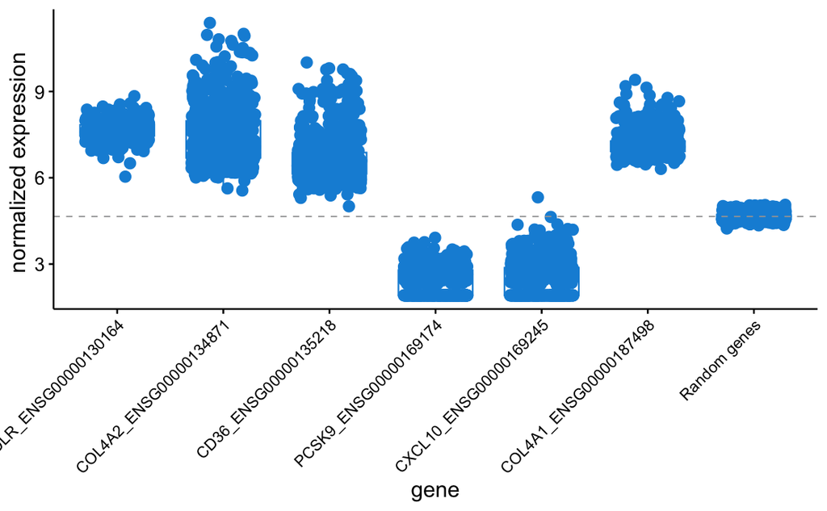

```r
  # mutate(gene = factor(gene, levels = c("Random genes", gene_list_qc)))

mean_1000_genes <- mean(expression_data_sample_mean$expression_value_sample)
# head(expression_long2)
#

  p1 <- ggpubr::ggboxplot(expression_long2,
                          x = "gene",
                          y = "expression_value",
                          color = uithof_color[16],
                          add = "jitter",
                          add.params = list(size = 3, jitter = 0.3),
                          ylab = paste0("normalized expression ")
                          ) +
    geom_hline(yintercept = mean_1000_genes, linetype = "dashed", color = uithof_color[26], size = 0.4) +
    theme(axis.text.x = element_text(size = 10, angle = 45, hjust = 1, vjust = 1), # change orientation of x-axis labels
          axis.text.y = element_text(size = 12),
          axis.title.x = element_text(size = 14),
          axis.title.y = element_text(size = 14))
  p1

  ggsave(filename = paste0(PLOT_loc, "/", Today, ".TargetExpression_vs_1000genes.png"), plot = last_plot())
  ggsave(filename = paste0(PLOT_loc, "/", Today, ".TargetExpression_vs_1000genes.pdf"), plot = last_plot())
  ggsave(filename = paste0(PLOT_loc, "/", Today, ".TargetExpression_vs_1000genes.ps"), plot = last_plot())
```

```r
  rm(p1, temp )
```

## Heatmaps for genes of interest

**Figure 4: correlation heatmap between expression of genes of interest**

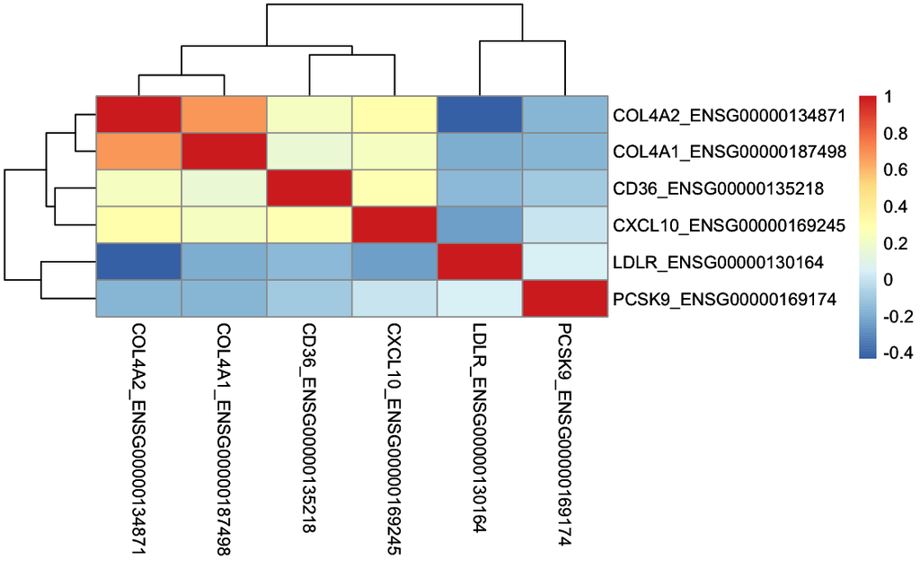

```r
library(tidyverse)
library(magrittr)

temp <- expression_wide %>%
  column_to_rownames("study_number") %>%
  dplyr::select(symbol_ensembl_gene_list_qc) %>%
  drop_na() %>% # drop NA
  Filter(function(x) sd(x) != 0, .) # filter variables with sd = 0

temp.cor <- cor(temp, method = "spearman")

p1 <- pheatmap(data.matrix(temp.cor),
               scale = "none",
               cluster_rows = TRUE,
               cluster_cols = TRUE,
               legend = TRUE,
               fontsize = 10)
p1
```

```r
ggsave(filename = paste0(PLOT_loc, "/", Today, ".correlations.gene_list.pdf"), plot = p1, height = 15, width = 15)

ggsave(filename = paste0(PLOT_loc, "/", Today, ".correlations.gene_list.png"), plot = p1, height = 15, width = 15)


rm(temp, temp.cor, p1)
```

# Gene target list

We are saving the final list of genes of interest

```r
temp <- subset(expression_data_sel, select = c("gene_ensembl", "symbol"))

fwrite(temp,
       file = paste0(OUT_loc, "/", Today, ".target_list.qc.txt"),
       sep = " ", row.names = FALSE, col.names = TRUE,
       showProgress = TRUE)
rm(temp)
```

# Saving AERNA data

We will create a list of samples that should be included based on CEA, and having the proper informed consent (‘academic’). We will save the `SummarizedExperiment` as a RDS file for easy loading. The clinical data will also be saved as a separate `txt`-file.

## Prepare meta data

```r
cat("  > meta data\n")
```

```
  > meta data
```

```r
temp_coldat <- data.frame(STUDY_NUMBER = names(bulkRNA_countsFilt[,10:631]),
                          SampleType = "plaque", RNAseqType = "3' RNAseq",
                          row.names = names(bulkRNA_countsFilt[,10:631]))
cat("  > clinical data\n")
```

```
  > clinical data
```

```r
# bulkRNA_meta_clin_COMMERCIAL <- subset(bulkRNA_meta_clin, select = c("study_number", basetable_vars))
bulkRNA_meta_clin_ACADEMIC <- subset(bulkRNA_meta_clin, select = c("study_number", "batch", "batchnr", "pool", basetable_vars))

# temp_coldat_clin <- merge(temp_coldat, bulkRNA_meta_clin_COMMERCIAL, by.x = "STUDY_NUMBER", by.y = "study_number", sort = FALSE, all.x = TRUE)
temp_coldat_clin <- merge(temp_coldat, bulkRNA_meta_clin_ACADEMIC, by.x = "STUDY_NUMBER", by.y = "study_number", sort = FALSE, all.x = TRUE)

rownames(temp_coldat_clin) <- temp_coldat_clin$STUDY_NUMBER
dim(temp_coldat_clin)
```

```
[1] 622  64
```

## The raw data

```r
# temp <- subset(bulkRNA_meta_clin_COMMERCIAL, select = c("study_number", "batch", "batchnr", "pool"))
# fwrite(temp,
#        file = paste0(OUT_loc, "/", Today, ".AERNA.CEA.608pts.samplelist.after_qc.IC_commercial.csv"),
#        sep = ",", row.names = FALSE, col.names = TRUE,
#        showProgress = TRUE)
# rm(temp)
#
# temp <- as.tibble(colData(AERNASE))
#
# fwrite(temp,
#        file = paste0(OUT_loc, "/", Today, ".AERNA.CEA.608pts.clinicaldata.after_qc.IC_commercial.csv"),
#        sep = ",", row.names = FALSE, col.names = TRUE,
#        showProgress = TRUE)
# rm(temp)

temp <- subset(bulkRNA_meta_clin_ACADEMIC, select = c("study_number", "batch", "batchnr", "pool"))
fwrite(temp,
       file = paste0(OUT_loc, "/", Today, ".AERNA.CEA.622pts.samplelist.after_qc.IC_academic.csv"),
       sep = ",", row.names = FALSE, col.names = TRUE,
       showProgress = TRUE)
rm(temp)

fwrite(bulkRNA_meta_clin_ACADEMIC,
       file = paste0(OUT_loc, "/", Today, ".AERNA.CEA.622pts.clinicaldata.after_qc.IC_academic.csv"),
       sep = ",", row.names = FALSE, col.names = TRUE,
       showProgress = TRUE)

temp <- as.tibble(assay(AERNASE))
fwrite(temp,
       file = paste0(OUT_loc, "/", Today, ".AERNA.CEA.622pts.assay.after_qc.IC_academic.csv"),
       sep = ",", row.names = FALSE, col.names = TRUE,
       showProgress = TRUE)
rm(temp)

temp <- as.tibble(rowRanges(AERNASE))
fwrite(temp,
       file = paste0(OUT_loc, "/", Today, ".AERNA.CEA.622pts.genedata.after_qc.IC_academic.csv"),
       sep = ",", row.names = FALSE, col.names = TRUE,
       showProgress = TRUE)
rm(temp)
```

## Normalized counts

Applied size correction before normalization.

```r
(AERNASEnorm <- SummarizedExperiment(assays = list(counts = normalized_counts),
                                colData = temp_coldat_clin,
                                rowRanges = bulkRNA_rowRanges,
                                metadata = "Athero-Express Biobank Study bulk RNA sequencing. Sample type: carotid plaques. Technology: CEL2-seq adapted for bulk RNA sequencing, thus 3'-focused. UMI-corrected. Size corrected normalization."))
```

```
class: RangedSummarizedExperiment
dim: 19884 622
metadata(1): ''
assays(1): counts
rownames(19884): ENSG00000000005 ENSG00000000419 ... ENSG00000273431 ENSG00000273457
rowData names(3): feature_id symbol GENEBIOTYPE_EnsDb86
colnames(622): ae1 ae1026 ... ae998 ae999
colData names(64): STUDY_NUMBER SampleType ... PCSK9_plasma PCSK9_plasma_rankNorm
```

```r
temp <- as.tibble(subset(colData(AERNASEnorm), select = c("STUDY_NUMBER", "SampleType", "RNAseqType","batch", "batchnr", "pool")))

# fwrite(temp,
#        file = paste0(OUT_loc, "/", Today, ".AERNA.CEA.608pts.samplelist.after_qc.IC_commercial.csv"),
#        sep = ",", row.names = FALSE, col.names = TRUE,
#        showProgress = TRUE)
# rm(temp)
#
# temp <- as.tibble(colData(AERNASE))
#
# fwrite(temp,
#        file = paste0(OUT_loc, "/", Today, ".AERNA.CEA.608pts.clinicaldata.after_qc.IC_commercial.csv"),
#        sep = ",", row.names = FALSE, col.names = TRUE,
#        showProgress = TRUE)
# rm(temp)

fwrite(temp,
       file = paste0(OUT_loc, "/", Today, ".AERNASEnorm.CEA.622pts.samplelist.after_qc.IC_academic.csv"),
       sep = ",", row.names = FALSE, col.names = TRUE,
       showProgress = TRUE)
rm(temp)

temp <- as.tibble(colData(AERNASEnorm))

fwrite(temp,
       file = paste0(OUT_loc, "/", Today, ".AERNASEnorm.CEA.622pts.clinicaldata.after_qc.IC_academic.csv"),
       sep = ",", row.names = FALSE, col.names = TRUE,
       showProgress = TRUE)
rm(temp)
```

```r
temp <- as_tibble(assay(AERNASEnorm))

fwrite(temp,
       file = paste0(OUT_loc, "/", Today, ".AERNASEnorm.CEA.622pts.assay.after_qc.IC_academic.csv"),
       sep = ",", row.names = FALSE, col.names = TRUE,
       showProgress = TRUE)
rm(temp)

temp <- as_tibble(rowRanges(AERNASEnorm))

fwrite(temp,
       file = paste0(OUT_loc, "/", Today, ".AERNASEnorm.CEA.622pts.genedata.after_qc.IC_academic.csv"),
       sep = ",", row.names = FALSE, col.names = TRUE,
       showProgress = TRUE)
rm(temp)
```

### Melting normalized data

```r
library("mia")
molten_AERNASEnorm <- mia::meltAssay(AERNASEnorm,
                             assay.type = "counts",
                             add_row_data = TRUE
                             )
head(molten_AERNASEnorm)
```

| FeatureID | SampleID | counts | feature_id | symbol | GENEBIOTYPE_EnsDb86 |
| --- | --- | --- | --- | --- | --- |
| ENSG00000000005 | ae1 | 0.000000 | ENSG00000000005 | TNMD | protein_coding |
| ENSG00000000005 | ae1026 | 0.000000 | ENSG00000000005 | TNMD | protein_coding |
| ENSG00000000005 | ae1029 | 0.000000 | ENSG00000000005 | TNMD | protein_coding |
| ENSG00000000005 | ae1032 | 4.179293 | ENSG00000000005 | TNMD | protein_coding |
| ENSG00000000005 | ae1054 | 1.380401 | ENSG00000000005 | TNMD | protein_coding |
| ENSG00000000005 | ae1055 | 0.000000 | ENSG00000000005 | TNMD | protein_coding |

```r
NA
```

## Log transformed counts

Log-transform the counts using `vst`.

```r
(AERNASEvst <- SummarizedExperiment(assays = list(counts = assay(AERNAvsd)),
                                colData = temp_coldat_clin,
                                rowRanges = bulkRNA_rowRanges,
                                metadata = "Athero-Express Biobank Study bulk RNA sequencing. Sample type: carotid plaques. Technology: CEL2-seq adapted for bulk RNA sequencing, thus 3'-focused. UMI-corrected. Size corrected normalization. log-transformed."))
```

```
class: RangedSummarizedExperiment
dim: 19884 622
metadata(1): ''
assays(1): counts
rownames(19884): ENSG00000000005 ENSG00000000419 ... ENSG00000273431 ENSG00000273457
rowData names(3): feature_id symbol GENEBIOTYPE_EnsDb86
colnames(622): ae1 ae1026 ... ae998 ae999
colData names(64): STUDY_NUMBER SampleType ... PCSK9_plasma PCSK9_plasma_rankNorm
```

```r
temp <- as.tibble(subset(colData(AERNASEvst), select = c("STUDY_NUMBER", "SampleType", "RNAseqType", "batch", "batchnr", "pool")))

# fwrite(temp,
#        file = paste0(OUT_loc, "/", Today, ".AERNA.CEA.608pts.samplelist.after_qc.IC_commercial.csv"),
#        sep = ",", row.names = FALSE, col.names = TRUE,
#        showProgress = TRUE)
# rm(temp)
#
# temp <- as.tibble(colData(AERNASE))
#
# fwrite(temp,
#        file = paste0(OUT_loc, "/", Today, ".AERNA.CEA.608pts.clinicaldata.after_qc.IC_commercial.csv"),
#        sep = ",", row.names = FALSE, col.names = TRUE,
#        showProgress = TRUE)
# rm(temp)

fwrite(temp,
       file = paste0(OUT_loc, "/", Today, ".AERNASEvst.CEA.622pts.samplelist.after_qc.IC_academic.csv"),
       sep = ",", row.names = FALSE, col.names = TRUE,
       showProgress = TRUE)
rm(temp)

temp <- as.tibble(colData(AERNASEvst))

fwrite(temp,
       file = paste0(OUT_loc, "/", Today, ".AERNASEvst.CEA.622pts.clinicaldata.after_qc.IC_academic.csv"),
       sep = ",", row.names = FALSE, col.names = TRUE,
       showProgress = TRUE)
rm(temp)
```

```r
temp <- as_tibble(assay(AERNASEvst))

fwrite(temp,
       file = paste0(OUT_loc, "/", Today, ".AERNASEvst.CEA.622pts.assay.after_qc.IC_academic.csv"),
       sep = ",", row.names = FALSE, col.names = TRUE,
       showProgress = TRUE)
rm(temp)

temp <- as_tibble(rowRanges(AERNASEvst))

fwrite(temp,
       file = paste0(OUT_loc, "/", Today, ".AERNASEvst.CEA.622pts.genedata.after_qc.IC_academic.csv"),
       sep = ",", row.names = FALSE, col.names = TRUE,
       showProgress = TRUE)
rm(temp)
```

### Melting log-transformed data

```r
molten_AERNASEvst <- mia::meltAssay(AERNASEvst,
                             assay.type = "counts",
                             add_row_data = TRUE
                             )
head(molten_AERNASEvst)
```

| FeatureID | SampleID | counts | feature_id | symbol | GENEBIOTYPE_EnsDb86 |
| --- | --- | --- | --- | --- | --- |
| ENSG00000000005 | ae1 | 1.910489 | ENSG00000000005 | TNMD | protein_coding |
| ENSG00000000005 | ae1026 | 1.910489 | ENSG00000000005 | TNMD | protein_coding |
| ENSG00000000005 | ae1029 | 1.910489 | ENSG00000000005 | TNMD | protein_coding |
| ENSG00000000005 | ae1032 | 3.368751 | ENSG00000000005 | TNMD | protein_coding |
| ENSG00000000005 | ae1054 | 2.771856 | ENSG00000000005 | TNMD | protein_coding |
| ENSG00000000005 | ae1055 | 1.910489 | ENSG00000000005 | TNMD | protein_coding |

```r
NA
```

## Compare raw, normalized, and log-transformed data

Here we just do a sanity check and compare the expression for a favorite gene.

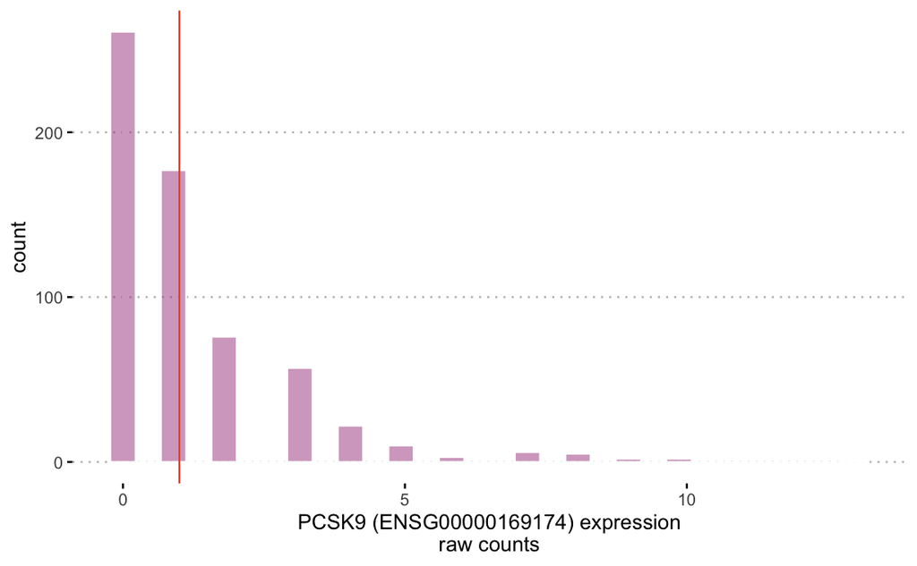

```r
ggpubr::gghistogram(as.tibble(t(subset(assay(AERNASE), AERNASE@rowRanges$symbol == "PCSK9"))),
                    x = "ENSG00000169174",
                    xlab = "PCSK9 (ENSG00000169174) expression\nraw counts",
                    color = "white", fill =  uithof_color[8],
                    rug = F, add_density = F,
                    add = c("median"),
                    add.params = list(color = uithof_color[3]),
                    ggtheme = theme_pubclean())
```

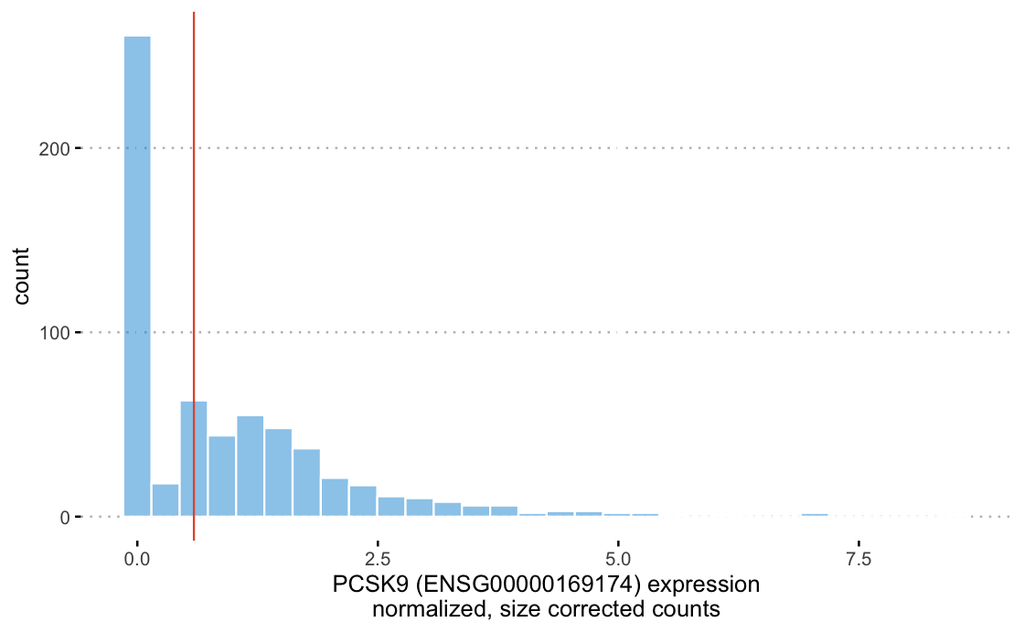

```r
ggpubr::gghistogram(as.tibble(t(subset(assay(AERNASEnorm), AERNASEnorm@rowRanges$symbol == "PCSK9"))),
                    x = "ENSG00000169174",
                    xlab = "PCSK9 (ENSG00000169174) expression\nnormalized, size corrected counts",
                    color = "white", fill =  uithof_color[17],
                    rug = F, add_density = F,
                    add = c("median"),
                    add.params = list(color = uithof_color[3]),
                    ggtheme = theme_pubclean())
```

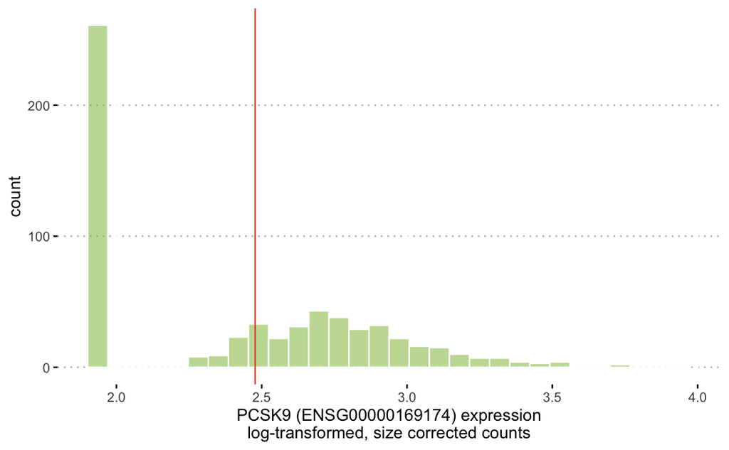

```r
ggpubr::gghistogram(as.tibble(t(subset(assay(AERNASEvst), AERNASEvst@rowRanges$symbol == "PCSK9"))),
                    x = "ENSG00000169174",
                    xlab = "PCSK9 (ENSG00000169174) expression\nlog-transformed, size corrected counts",
                    color = "white", fill =  uithof_color[20],
                    rug = F, add_density = F,
                    add = c("median"),
                    add.params = list(color = uithof_color[3]),
                    ggtheme = theme_pubclean())
```

## Saving the datasets

```r
# saveRDS(AERNASE, file = paste0(OUT_loc, "/", Today, ".AERNA.CEA.608pts.SE.after_qc.IC_commercial.RDS"))
saveRDS(AERNASE, file = paste0(OUT_loc, "/", Today, ".AERNA.CEA.622pts.SE.after_qc.IC_academic.RDS"))
saveRDS(AERNASEnorm, file = paste0(OUT_loc, "/", Today, ".AERNASEnorm.CEA.622pts.SE.after_qc.IC_academic.RDS"))
saveRDS(AERNASEvst, file = paste0(OUT_loc, "/", Today, ".AERNASEvst.CEA.622pts.SE.after_qc.IC_academic.RDS"))
```

# Session information

```
Version:      v1.1.1
Last update:  2023-06-14
Written by:   Sander W. van der Laan (s.w.vanderlaan-2[at]umcutrecht.nl).
Description:  Script to load bulk RNA sequencing data, and perform gene expression analyses, and visualisations.
Minimum requirements: R version 3.5.2 (2018-12-20) -- 'Eggshell Igloo', macOS Mojave (10.14.2).

**MoSCoW To-Do List**
The things we Must, Should, Could, and Would have given the time we have.
_M_

_S_

_C_

_W_

**Changes log**
* v1.1.1 Fixed baseline table writing. Additional versions of saved data. Added example to 'melt' data using `mia`.
* v1.1.0 Update to bulk RNAseq data - deeper sequencing data is now available. Update to the study database.
* v1.0.1 Fixes to annotation. Fix to loading clinical dataset.
* v1.0.0 Inital version. Update to the count data, gene list. Filter samples based on artery operated (CEA) and informed consent. Added heatmap of correlation between target genes.
```

# Saving environment

```r
rm(molten_AERNASEnorm, molten_AERNASEvst)
save.image(paste0(PROJECT_loc, "/",Today,".",PROJECTNAME,".bulkRNAseq.preparation.RData"))
```

| <sup>© 1979-2023 Sander W. van der Laan \| s.w.vanderlaan[at]gmail.com \| vanderlaan.science.</sup> \| |
| --- |